# R Notebook: Multinomial Logit

## Packages

Make sure the following packages are installed before proceeding:

1. xtable
2. knitr
3. mlogit
4. caret
5. e1071

```r
library("xtable") # processing of regression output
library("knitr") # used for report compilation and table display
library("ggplot2") # very popular plotting library ggplot2
library("ggthemes") # themes for ggplot2
suppressMessages(library("mlogit")) # multinomial logit
library("caret")
```

## Multinomial logit

Multinomial logit, in contrast to simple binomial logisic regression, is used for modeling choices among multiple alternatives.

Once the choice model has been estimated, we can use the parameter estimates to assess relative importance of different attributes in predicting the probability of choice.

## Data

You will work with provided *trasportation_data.csv* file.

```r
data <- read.csv(file = "./data/transportation_data.csv")
```

The file contains data 210 travelers making a choice between 4 different modes of transport (plane, train, bus, car). Each traveler made a choice only once. Each alternative is a new row, so there are 4 rows per traveler – sequentially. Thus, the file contains 210 * 4 = 840 rows.

```r
kable(head(data,8))
```

| TRAVELER | MODE | TTME | INVC | INVT | HINC |
| --- | --- | --- | --- | --- | --- |
| 1 | 0 | 69 | 59 | 100 | 35 |
| 1 | 0 | 34 | 31 | 372 | 35 |
| 1 | 0 | 35 | 25 | 417 | 35 |
| 1 | 1 | 0 | 10 | 180 | 35 |
| 2 | 0 | 64 | 58 | 68 | 30 |
| 2 | 0 | 44 | 31 | 354 | 30 |
| 2 | 0 | 53 | 25 | 399 | 30 |
| 2 | 1 | 0 | 11 | 255 | 30 |

In the table above, for example, the first four rows (1:4) form a choice set for the first traveler. Rows (5:8) are the choice set of the second traveler, and so on.

Column 1 “Traveler” is traveler’s id, column “Mode” helps identify which alternative was chosen by the traveler from the choice set – it contains 1 if the row represents the mode of transportation the traveler chose, and 0 otherwise. Per traveler, rows map to modes of transportaion in the following order:

1 - plane (air) 2 - train 3 - bus 4 - car

TTME, INVC, INVT are variables that describe the options, whereas HINC describes the traveler.

- TTME = terminal waiting time for plane, train and bus (minutes); 0 for car.
- INVC = in-vehicle cost (dollars).
- INVT = travel time (minutes).
- HINC = household income ($1000s).

All variables are treated as continuous.

## Descriptive statistics

```r
transp_dec<-rbind(
colSums(data[seq(1, nrow(data), 4), ])/210,
colSums(data[seq(2, nrow(data), 4), ])/210,
colSums(data[seq(3, nrow(data), 4), ])/210,
colSums(data[seq(4, nrow(data), 4), ])/210)
transp_dec<-transp_dec[,c(2:5)]
colnames(transp_dec) <- c('CHOICE SHARE','AVG. WAITING TTME', 'AVG. COST', 'AVG. TRAVEL TIME')
kable(transp_dec)
```

| CHOICE SHARE | AVG. WAITING TTME | AVG. COST | AVG. TRAVEL TIME |
| --- | --- | --- | --- |
| 0.2761905 | 61.00952 | 85.25238 | 133.7095 |
| 0.3000000 | 35.69048 | 51.33810 | 608.2857 |
| 0.1428571 | 41.65714 | 33.45714 | 629.4619 |
| 0.2809524 | 0.00000 | 20.99524 | 573.2048 |

```r
Household_Income <- data[seq(1, nrow(data), 4), 6]
summary(Household_Income)
```

```
   Min. 1st Qu.  Median    Mean 3rd Qu.    Max.
   2.00   20.00   34.50   34.55   50.00   72.00
```

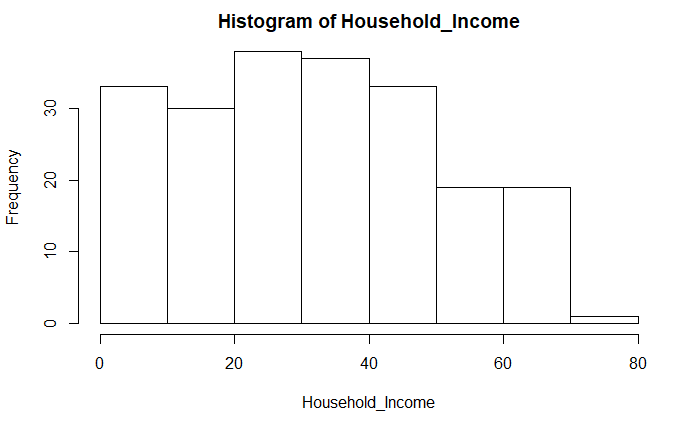

```r
hist(Household_Income)
```

## MNL model estimation - product attributes only

Based on the provided data, we will estimate the multinomial logit model.

First, we estimate a model that is trained just using 3 variables that describe the alternatives (TTME, INVC, INVT) and intercept corresponding to trasportation mode (normalizing plane intercept to zero, $\beta_{01}=0$). That is,
$$\begin{align*}
V_j = & \beta_{0j}+\beta_{1}\text{TTME}_j + \beta_{2}\text{INVC}_j + \beta_{3}\text{INVT}_j
\end{align*}$$
$U_j = V_j + \text{error}$. Assuming independent extreme value error distribution, traveler chooses mode of transportation $j$ from the choice set of four alternatives with probability
$$p_j = \frac{\exp(V_j)}{\exp(V_1)+\exp(V_2)+\exp(V_3)+\exp(V_4)},\ \ j\in\{1,2,3,4\}$$

Clearly, $p_1+p_2+p_3+p_4=1$

```r
require('mlogit')
mdata <- mlogit.data(data=data,
                     choice='MODE', # variable that contains choice
                     shape='long', # tells mlogit how data is structured (every row is alternative)
                     varying=3:5, # only select variables that describe the alternatives
                     alt.levels = c("plane", "train", "bus", "car"), # levels of the alternatives
                     id.var='TRAVELER') # consumer id
head(mdata,6)
```

|  | TRAVELER | MODE | TTME | INVC | INVT | HINC |
| --- | --- | --- | --- | --- | --- | --- |
| 1.plane | 1 | FALSE | 69 | 59 | 100 | 35 |
| 1.train | 1 | FALSE | 34 | 31 | 372 | 35 |
| 1.bus | 1 | FALSE | 35 | 25 | 417 | 35 |
| 1.car | 1 | TRUE | 0 | 10 | 180 | 35 |
| 2.plane | 2 | FALSE | 64 | 58 | 68 | 30 |
| 2.train | 2 | FALSE | 44 | 31 | 354 | 30 |

```r
set.seed(999)
model <- mlogit(MODE~TTME+INVC+INVT,data=mdata)
summary(model)
```

```
Call:
mlogit(formula = MODE ~ TTME + INVC + INVT, data = mdata, method = "nr")

Frequencies of alternatives:
  plane   train     bus     car
0.27619 0.30000 0.14286 0.28095

nr method
5 iterations, 0h:0m:0s
g'(-H)^-1g = 0.000192
successive function values within tolerance limits

Coefficients :
                     Estimate  Std. Error z-value  Pr(>|z|)
train:(intercept) -0.78666667  0.60260733 -1.3054   0.19174
bus:(intercept)   -1.43363372  0.68071345 -2.1061   0.03520 *
car:(intercept)   -4.73985647  0.86753178 -5.4636 4.665e-08 ***
TTME              -0.09688675  0.01034202 -9.3683 < 2.2e-16 ***
INVC              -0.01391160  0.00665133 -2.0916   0.03648 *
INVT              -0.00399468  0.00084915 -4.7043 2.547e-06 ***
---
Signif. codes:  0 ‘***’ 0.001 ‘**’ 0.01 ‘*’ 0.05 ‘.’ 0.1 ‘ ’ 1

Log-Likelihood: -192.89
McFadden R^2:  0.32024
Likelihood ratio test : chisq = 181.74 (p.value = < 2.22e-16)
```

## Interpretation

- Output of the model is relative to what was set in the intersept
  - In this case, as air is the base, the negative means that air has a higher intrinsic utility than bus or car keeping everything else constant. Train values are not statistically significant.
- t-value or standardised coeficient should be used instead as a comparison. MUST STANDARDISE INDEPENDENT VARIABLES BEFORE RUNNING MODEL TO PROPERLY COMPARE THE COEFFICIENTS.

Here is how likelihood ratio test is done, more explicitly.

```r
model.null <- mlogit(MODE~1,data=mdata)
lrtest(model,model.null)
```

```
Likelihood ratio test

Model 1: MODE ~ TTME + INVC + INVT
Model 2: MODE ~ 1
  #Df  LogLik Df  Chisq Pr(>Chisq)
1   6 -192.89
2   3 -283.76 -3 181.74  < 2.2e-16 ***
---
Signif. codes:  0 ‘***’ 0.001 ‘**’ 0.01 ‘*’ 0.05 ‘.’ 0.1 ‘ ’ 1
```

We can also use the estimated parameters to predict the probabilities of the choice for different trasportation modes in the data. Here we print the prediction for the first traveler in the data.

```r
kable(head(predict(model,mdata),1))
```

| plane | train | bus | car |
| --- | --- | --- | --- |
| 0.0483305 | 0.3255135 | 0.1405072 | 0.4856488 |

And now we can measure the accuracy of prediction across all data.

```r
predicted_alternative <- apply(predict(model,mdata),1,which.max)
selected_alternative <- rep(1:4,210)[data$MODE>0]
confusionMatrix(table(predicted_alternative,selected_alternative))
```

```
Confusion Matrix and Statistics

                     selected_alternative
predicted_alternative  1  2  3  4
                    1 39  6  3  7
                    2  4 49  3  8
                    3  0  1 23  0
                    4 15  7  1 44

Overall Statistics

               Accuracy : 0.7381
                 95% CI : (0.6731, 0.7962)
    No Information Rate : 0.3
    P-Value [Acc > NIR] : <2e-16

                  Kappa : 0.6414

 Mcnemar's Test P-Value : 0.2118

Statistics by Class:

                     Class: 1 Class: 2 Class: 3 Class: 4
Sensitivity            0.6724   0.7778   0.7667   0.7458
Specificity            0.8947   0.8980   0.9944   0.8477
Pos Pred Value         0.7091   0.7656   0.9583   0.6567
Neg Pred Value         0.8774   0.9041   0.9624   0.8951
Prevalence             0.2762   0.3000   0.1429   0.2810
Detection Rate         0.1857   0.2333   0.1095   0.2095
Detection Prevalence   0.2619   0.3048   0.1143   0.3190
Balanced Accuracy      0.7836   0.8379   0.8806   0.7967
```

Note that if the predictions were random, the accuracy would be 25% (for four alternatives). Our simple model is doing much better than that – although it is not perfect.

## Model with demographics

Now we will estimate a model that also includes a demographic variable – household income. However, we cannot just include it as an ordinary alternative-specific variable – this is because demographics for one individual would be the same across all alternatives, and so would cancel out from the probability expression as follows (so we cannot estimate the parameter $\beta_4$)

$$\begin{align*}
p_{bus} &= \frac{\exp(\cdots_{bus} + \beta_4 \text{HINC})}{\exp(\cdots_{car} + \beta_4 \text{HINC}) + \cdots + \exp(\cdots_{plane} + \beta_4 \text{HINC})}\\
&= \frac{\exp(\cdots_{bus})\exp(\beta_4 \text{HINC})}{\exp(\cdots_{car})\exp(\beta_4 \text{HINC}) + \cdots + \exp(\cdots_{plane})\exp(\beta_4 \text{HINC})}\\
&= \frac{\exp(\cdots_{bus})}{\exp(\cdots_{car}) + \cdots + \exp(\cdots_{plane})}
\end{align*}$$

To deal with this issue, we need to interact the demographic variable with a dummy code for each alternative and then estimate the model. Specifically, we are now estimating utility equation where

$$\begin{align*}
V_j = & \alpha_{0j} + \alpha_{1j}HouseholdIncome +\beta_{1}\text{TTME}_j + \beta_{2}\text{INVC}_j + \beta_{3}\text{INVT}_j
\end{align*}$$

with intercept terms for air normalized to zero: $\alpha_{01}=\alpha_{11}=0$. $\alpha_{0j}$ here has the same interpretation as an intercept term in no-demographics model – that is, inherent utility of a trasportation mode relative to travel by plane. And $\alpha_{1j}$ now measures additional (dis)utility from a trasportation mode at higher income level (again, relative to the plane).

This is how we would estimate the model

```r
model1 <- mlogit(MODE~TTME+INVC+INVT|HINC,data=mdata)
summary(model1)
```

```
Call:
mlogit(formula = MODE ~ TTME + INVC + INVT | HINC, data = mdata,
    method = "nr")

Frequencies of alternatives:
  plane   train     bus     car
0.27619 0.30000 0.14286 0.28095

nr method
5 iterations, 0h:0m:0s
g'(-H)^-1g = 0.000546
successive function values within tolerance limits

Coefficients :
                     Estimate  Std. Error z-value  Pr(>|z|)
train:(intercept)  1.24212398  0.81686459  1.5206  0.128360
bus:(intercept)   -0.18436561  0.89664384 -0.2056  0.837090
car:(intercept)   -4.24742503  1.00650942 -4.2200 2.444e-05 ***
TTME              -0.09528341  0.01035524 -9.2015 < 2.2e-16 ***
INVC              -0.00449878  0.00721124 -0.6239  0.532722
INVT              -0.00366471  0.00086797 -4.2222 2.420e-05 ***
train:HINC        -0.05589505  0.01535704 -3.6397  0.000273 ***
bus:HINC          -0.02311070  0.01645639 -1.4044  0.160212
car:HINC           0.00210282  0.01209542  0.1739  0.861982
---
Signif. codes:  0 ‘***’ 0.001 ‘**’ 0.01 ‘*’ 0.05 ‘.’ 0.1 ‘ ’ 1

Log-Likelihood: -182.22
McFadden R^2:  0.35784
Likelihood ratio test : chisq = 203.08 (p.value = < 2.22e-16)
```

And here is how we can use likelihood ratio test to test the second model against the first one.

```r
lrtest(model1,model)
```

```
Likelihood ratio test

Model 1: MODE ~ TTME + INVC + INVT | HINC
Model 2: MODE ~ TTME + INVC + INVT
  #Df  LogLik Df Chisq Pr(>Chisq)
1   9 -182.22
2   6 -192.89 -3 21.34  8.948e-05 ***
---
Signif. codes:  0 ‘***’ 0.001 ‘**’ 0.01 ‘*’ 0.05 ‘.’ 0.1 ‘ ’ 1
```

Let us look at the new confusion matrix.

```r
predicted_alternative <- apply(predict(model1,mdata),1,which.max)
selected_alternative <- rep(1:4,210)[data$MODE>0]
confusionMatrix(table(predicted_alternative,selected_alternative))
```

```
Confusion Matrix and Statistics

                     selected_alternative
predicted_alternative  1  2  3  4
                    1 40  6  1  7
                    2  5 50  3  9
                    3  0  1 23  0
                    4 13  6  3 43

Overall Statistics

               Accuracy : 0.7429
                 95% CI : (0.6782, 0.8005)
    No Information Rate : 0.3
    P-Value [Acc > NIR] : <2e-16

                  Kappa : 0.6477

 Mcnemar's Test P-Value : 0.2778

Statistics by Class:

                     Class: 1 Class: 2 Class: 3 Class: 4
Sensitivity            0.6897   0.7937   0.7667   0.7288
Specificity            0.9079   0.8844   0.9944   0.8543
Pos Pred Value         0.7407   0.7463   0.9583   0.6615
Neg Pred Value         0.8846   0.9091   0.9624   0.8897
Prevalence             0.2762   0.3000   0.1429   0.2810
Detection Rate         0.1905   0.2381   0.1095   0.2048
Detection Prevalence   0.2571   0.3190   0.1143   0.3095
Balanced Accuracy      0.7988   0.8390   0.8806   0.7916
```

```r
mdata.new <- mdata
mdata.new[seq(2,840,4),"INVT"] <- 0.9*mdata.new[seq(2,840,4),"INVT"]
predicted_alternative_new <- apply(predict(model1,mdata.new),1,which.max)

table(predicted_alternative)/210 # probability under original data
```

```
predicted_alternative
        1         2         3         4
0.2571429 0.3190476 0.1142857 0.3095238
```

```r
table(predicted_alternative_new)/210 # probability after decrease in train travel time
```

```
predicted_alternative_new
        1         2         3         4
0.2523810 0.3380952 0.1095238 0.3000000
```

```r
(table(predicted_alternative_new) - table(predicted_alternative))/table(predicted_alternative)
```

```
predicted_alternative_new
          1           2           3           4
-0.01851852  0.05970149 -0.04166667 -0.03076923
```

## Interaction effects

Finally, we can also interact a demographic variable with product attributes. Let us do it and see whether including corresponding terms contributes to the model’s quality.

```r
model2 <- mlogit(MODE~TTME+INVC+INVT+TTME:HINC+INVC:HINC+INVT:HINC|HINC,data=mdata)
summary(model2)
```

```
Call:
mlogit(formula = MODE ~ TTME + INVC + INVT + TTME:HINC + INVC:HINC +
    INVT:HINC | HINC, data = mdata, method = "nr")

Frequencies of alternatives:
  plane   train     bus     car
0.27619 0.30000 0.14286 0.28095

nr method
5 iterations, 0h:0m:0s
g'(-H)^-1g = 1.24E-07
gradient close to zero

Coefficients :
                     Estimate  Std. Error z-value  Pr(>|z|)
train:(intercept)  2.7964e+00  1.3736e+00  2.0359 0.0417642 *
bus:(intercept)    1.3521e+00  1.4690e+00  0.9204 0.3573409
car:(intercept)   -2.2819e+00  1.7905e+00 -1.2745 0.2024902
TTME              -7.6820e-02  1.9786e-02 -3.8825 0.0001034 ***
INVC              -1.2090e-02  1.6351e-02 -0.7394 0.4596505
INVT              -6.4867e-03  1.8918e-03 -3.4288 0.0006063 ***
TTME:HINC         -6.1259e-04  5.6766e-04 -1.0791 0.2805255
INVC:HINC          2.3632e-04  4.0999e-04  0.5764 0.5643403
INVT:HINC          7.5168e-05  4.2332e-05  1.7757 0.0757833 .
train:HINC        -9.9571e-02  3.2746e-02 -3.0407 0.0023604 **
bus:HINC          -6.4966e-02  3.4688e-02 -1.8729 0.0610848 .
car:HINC          -5.4584e-02  4.5749e-02 -1.1931 0.2328209
---
Signif. codes:  0 ‘***’ 0.001 ‘**’ 0.01 ‘*’ 0.05 ‘.’ 0.1 ‘ ’ 1

Log-Likelihood: -180.1
McFadden R^2:  0.36529
Likelihood ratio test : chisq = 207.31 (p.value = < 2.22e-16)
```

```r
lrtest(model2,model1)
```

```
Likelihood ratio test

Model 1: MODE ~ TTME + INVC + INVT + TTME:HINC + INVC:HINC + INVT:HINC |
    HINC
Model 2: MODE ~ TTME + INVC + INVT | HINC
  #Df  LogLik Df  Chisq Pr(>Chisq)
1  12 -180.10
2   9 -182.22 -3 4.2295     0.2377
```

We find that adding such interaction terms does not improve model significantly.